# Homework 6

Murrel Pereira

11/24/2020

```r
library(tidyverse)
library(modelr)
library(p8105.datasets)
```

### Problem 1

```r
homicide_df =
  read_csv("data/homicide-data.csv", na = c("", "NA", "Unknown")) %>%
  mutate(
    city_state = str_c(city, state, sep = ", "),
    victim_age = as.numeric(victim_age),
    resolution = case_when(
      disposition == "Closed without arrest" ~ 0,
      disposition == "Open/No arrest"        ~ 0,
      disposition == "Closed by arrest"      ~ 1)
  ) %>%
  filter(
    victim_race %in% c("White", "Black"),
    city_state != "Tulsa, AL") %>%
  select(city_state, resolution, victim_age, victim_race, victim_sex)
```

Start with one city.

```r
baltimore_df =
  homicide_df %>%
  filter(city_state == "Baltimore, MD")
glm(resolution ~ victim_age + victim_race + victim_sex,
    data = baltimore_df,
    family = binomial()) %>%
  broom::tidy() %>%
  mutate(
    OR = exp(estimate),
    CI_lower = exp(estimate - 1.96 * std.error),
    CI_upper = exp(estimate + 1.96 * std.error)
  ) %>%
  select(term, OR, starts_with("CI")) %>%
  knitr::kable(digits = 3)
```

| term | OR | CI_lower | CI_upper |
| --- | --- | --- | --- |
| (Intercept) | 1.363 | 0.975 | 1.907 |
| victim_age | 0.993 | 0.987 | 1.000 |
| victim_raceWhite | 2.320 | 1.648 | 3.268 |
| victim_sexMale | 0.426 | 0.325 | 0.558 |

Try this across cities.

```r
models_results_df =
  homicide_df %>%
  nest(data = -city_state) %>%
  mutate(
    models =
      map(.x = data, ~glm(resolution ~ victim_age + victim_race + victim_sex, data = .x, family = binomial())),
    results = map(models, broom::tidy)
  ) %>%
  select(city_state, results) %>%
  unnest(results) %>%
  mutate(
    OR = exp(estimate),
    CI_lower = exp(estimate - 1.96 * std.error),
    CI_upper = exp(estimate + 1.96 * std.error)
  ) %>%
  select(city_state, term, OR, starts_with("CI"))
```

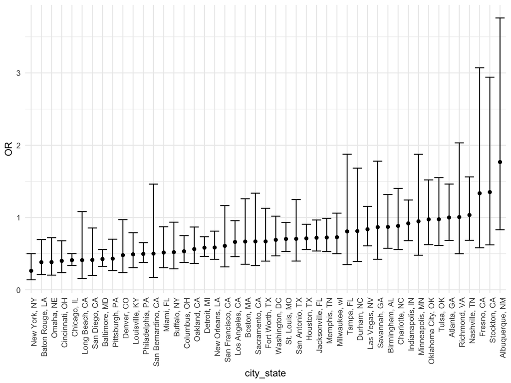

```r
models_results_df %>%
  filter(term == "victim_sexMale") %>%
  mutate(city_state = fct_reorder(city_state, OR)) %>%
  ggplot(aes(x = city_state, y = OR)) +
  geom_point() +
  geom_errorbar(aes(ymin = CI_lower, ymax = CI_upper)) +
  theme(axis.text.x = element_text(angle = 90, hjust = 1))
```

## Problem 2

Find some residuals

Load data

```r
baby_df =
  read_csv("./data/birthweight.csv")
baby_df =
  baby_df %>%
  mutate(
    babysex = as.factor(babysex),
   # bwt = as.factor(bwt),
    frace = as.factor(frace),
    malform = as.factor(malform),
    mrace = as.factor(mrace),
    parity = as.factor(parity),
    pnumlbw = as.factor(pnumlbw),
    pnumsga = as.factor(pnumsga)
  )
```

Proposed Model

```r
model_fit_proposal = lm(bwt ~ bhead + blength + babysex + gaweeks + mrace + fincome + smoken + ppbmi + bhead*babysex + blength*babysex + bhead*blength*babysex , data = baby_df)

model_fit_proposal %>%
  broom::tidy() %>%
  knitr::kable()
```

| term | estimate | std.error | statistic | p.value |
| --- | --- | --- | --- | --- |
| (Intercept) | -6126.6839466 | 1225.8009041 | -4.9981069 | 0.0000006 |
| bhead | 142.7584192 | 37.0313159 | 3.8550728 | 0.0001174 |
| blength | 79.8778185 | 25.4789937 | 3.1350461 | 0.0017298 |
| babysex2 | 5207.0680713 | 1617.0979782 | 3.2200078 | 0.0012913 |
| gaweeks | 12.6977203 | 1.4934445 | 8.5023049 | 0.0000000 |
| mrace2 | -131.0630235 | 10.0865710 | -12.9938136 | 0.0000000 |
| mrace3 | -97.2141319 | 42.9808014 | -2.2618036 | 0.0237590 |
| mrace4 | -130.5300851 | 19.2355294 | -6.7858847 | 0.0000000 |
| fincome | 0.3741134 | 0.1769027 | 2.1147982 | 0.0345042 |
| smoken | -4.1475701 | 0.5943438 | -6.9784024 | 0.0000000 |
| ppbmi | 4.9655989 | 1.3380085 | 3.7111863 | 0.0002089 |
| bhead:babysex2 | -160.8462859 | 49.2451153 | -3.2662384 | 0.0010984 |
| blength:babysex2 | -101.8597062 | 33.8428953 | -3.0097811 | 0.0026294 |
| bhead:blength | -0.0563038 | 0.7574711 | -0.0743312 | 0.9407503 |
| bhead:blength:babysex2 | 3.1650790 | 1.0183035 | 3.1081883 | 0.0018946 |

I picked this model by doing backwards stepwise with all main effects and interactions/three-way intractions for `blength`, `bhead`, and `babysex`. I used the criteria that the p-value had to be less than 0.05 for the model. Many of the physical characteristics of the baby (`bhead`, `blength`, `babysex`, `gaweeks`) and mom health and socioeconomic factors (`mrace`, `fincome`, `smoken`, `ppbmi`) made it into the model. Factors with just one level (`pnumsga` and `pnumlbw`) were not incorporated since these factors didn’t have enough levels.

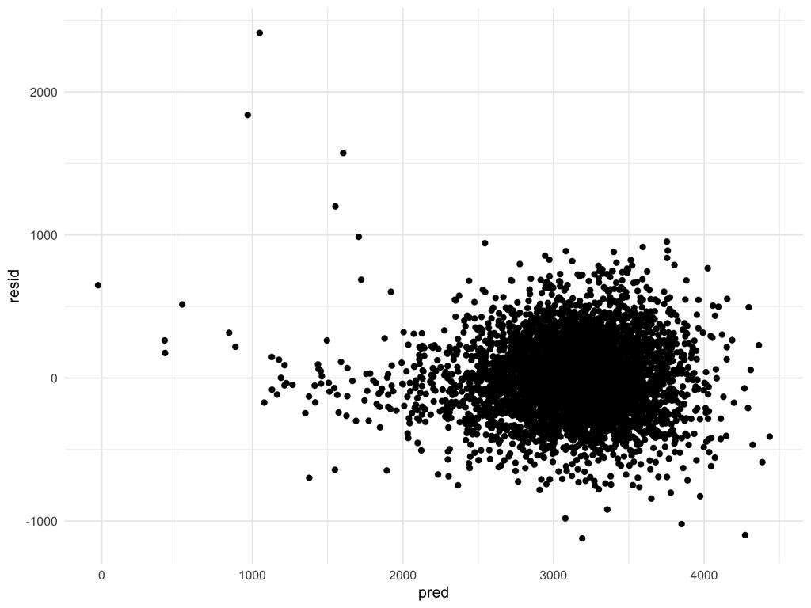

```r
baby_df %>%
  modelr::add_residuals(model_fit_proposal) %>%
  modelr::add_predictions(model_fit_proposal) %>%
  ggplot(aes(x = pred, y = resid)) +
  geom_point()
```

When looking at the residuals versus and predictions plot for the model, we notice that the residuals are spread evenly around 0 when the bwt prediction is above 2000 g. There might be some points under this weight that are outliers or cannot be explained by the factors in the model.

```r
cv_baby_df =
  crossv_mc(baby_df, 100) %>%
  mutate(
    train = map(train, as_tibble),
    test = map(test, as_tibble)) %>%
  mutate(
    model_fit_proposal = map(train, ~lm(bwt ~ bhead + blength + babysex + gaweeks + mrace + fincome + smoken + ppbmi + bhead*babysex + blength*babysex + bhead*blength*babysex , data = .x)),
    model_fit_a  = map(train, ~lm(bwt ~ gaweeks + blength, data = .x)),
    model_fit_b  = map(train, ~lm(bwt ~ bhead + blength + babysex + bhead*blength + bhead*babysex + blength*babysex + bhead*blength*babysex, sp = 10e-6, data = .x))
    ) %>%
  mutate(
    rmse_proposal = map2_dbl(model_fit_proposal, test, ~rmse(model = .x, data = .y)),
    rmse_fit_a = map2_dbl(model_fit_a, test, ~rmse(model = .x, data = .y)),
    rmse_fit_b = map2_dbl(model_fit_b, test, ~rmse(model = .x, data = .y))
  )
```

This graph compares the models to each other. As you can see from the RMSE plots, the proposed model has the lowest RMSE compared to model A and model B.

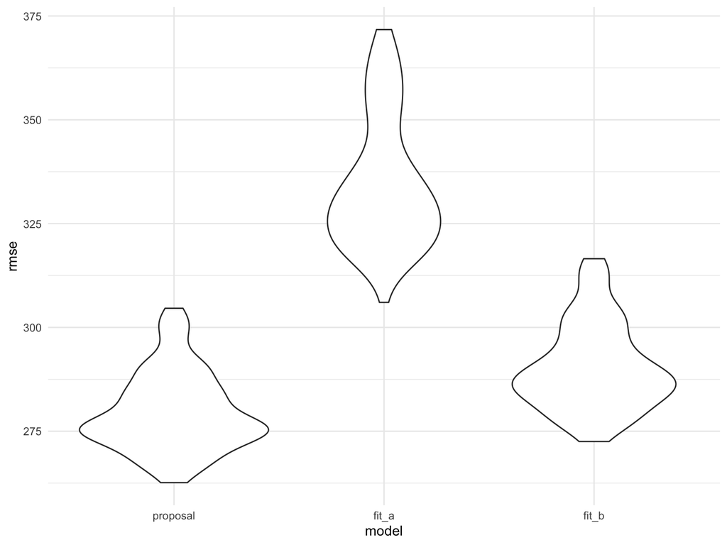

```r
cv_baby_df %>%
  select(starts_with("rmse")) %>%
  pivot_longer(
    everything(),
    names_to = "model",
    values_to = "rmse",
    names_prefix = "rmse_") %>%
  mutate(model = fct_inorder(model)) %>%
  ggplot(aes(x = model, y = rmse)) + geom_violin()
```

## Problem 3

```r
weather_df =
  rnoaa::meteo_pull_monitors(
    c("USW00094728"),
    var = c("PRCP", "TMIN", "TMAX"),
    date_min = "2017-01-01",
    date_max = "2017-12-31") %>%
  mutate(
    name = recode(id, USW00094728 = "CentralPark_NY"),
    tmin = tmin / 10,
    tmax = tmax / 10) %>%
  select(name, id, everything())
```

```
## using cached file: /Users/murrelpereira/Library/Caches/R/noaa_ghcnd/USW00094728.dly
```

```
## date created (size, mb): 2020-09-14 20:29:29 (7.518)
```

```
## file min/max dates: 1869-01-01 / 2020-09-30
```

Explore tmin and tmax relationship with a scatterplot

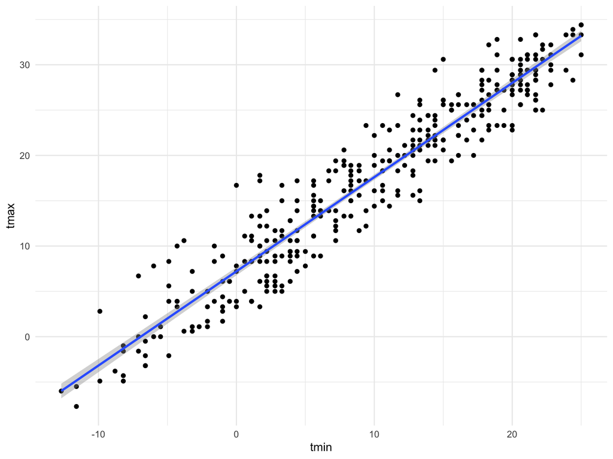

```r
weather_df %>%
  ggplot(aes(x = tmin, y = tmax)) + geom_point() + stat_smooth(method = "lm")
```

Bootstrap and model tmin and tmax. Clean up and wrangle in order to extract r_squared and calculate log(intercept_hat*tmin_hat).

```r
weather_df_bootstrap =
weather_df %>%
  modelr::bootstrap(n = 5000) %>%
  mutate(
    models = map(strap, ~lm(tmax ~ tmin, data = .x) ),
    results = map(models, broom::tidy),
    results_extra = map(models, broom::glance)) %>%
  select(-strap, -models) %>%
  unnest(results, results_extra)

weather_df_bootstrap =
  weather_df_bootstrap %>%
   select(.id:r.squared)

weather_df_bootstrap_2 =
  weather_df_bootstrap %>%
  select(.id, term, estimate, r.squared) %>%
  pivot_wider(
    id_cols = c(".id", "r.squared"),
    names_from = term,
    values_from = estimate
  ) %>%
  janitor::clean_names() %>%
  mutate(
    boot_log = log(intercept*tmin)
  )
```

Plot the distribution of estimates and r_squared and log(intercept_hat*tmin_hat)

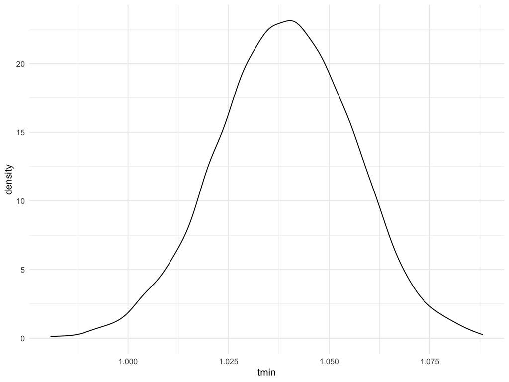

```r
weather_df_bootstrap_2 %>%
  ggplot(aes(x = tmin)) + geom_density()
```

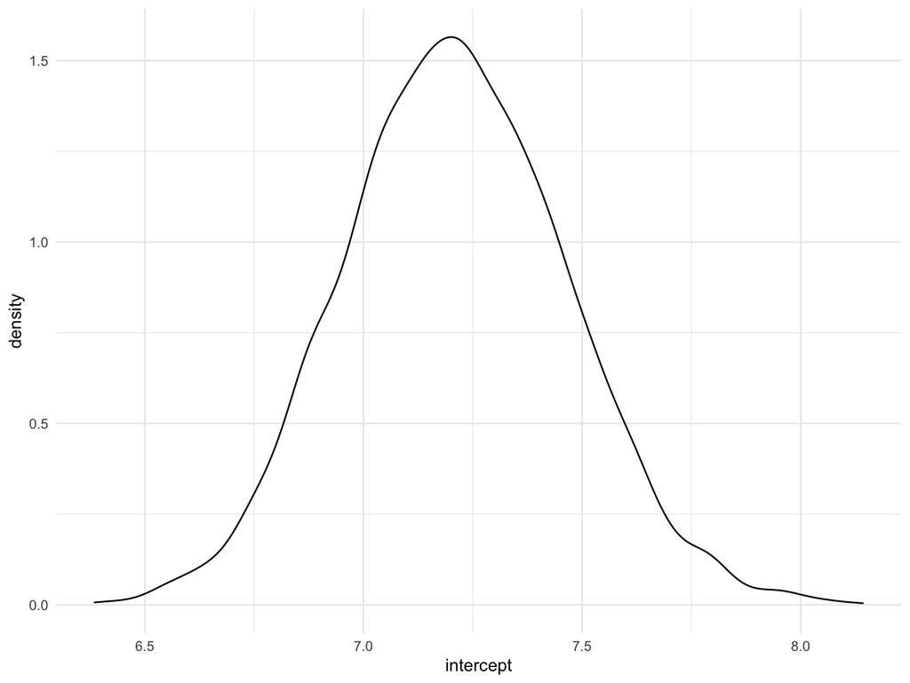

```r
weather_df_bootstrap_2 %>%
  ggplot(aes(x = intercept)) + geom_density()
```

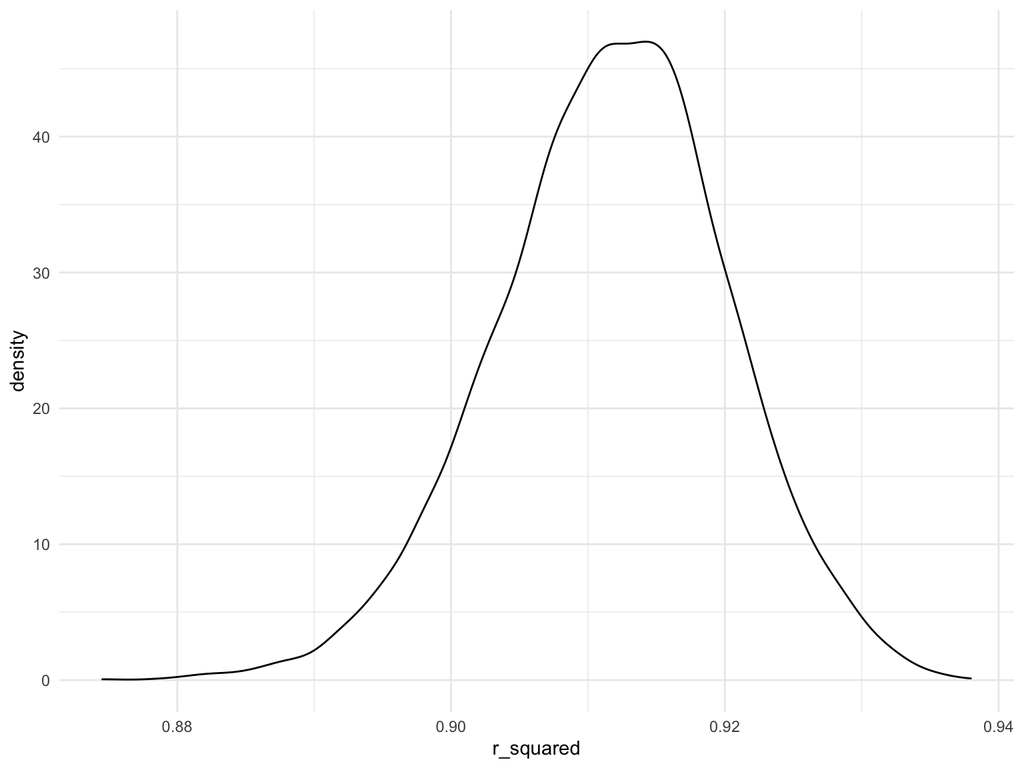

```r
weather_df_bootstrap_2 %>%
  ggplot(aes(x = r_squared)) + geom_density()
```

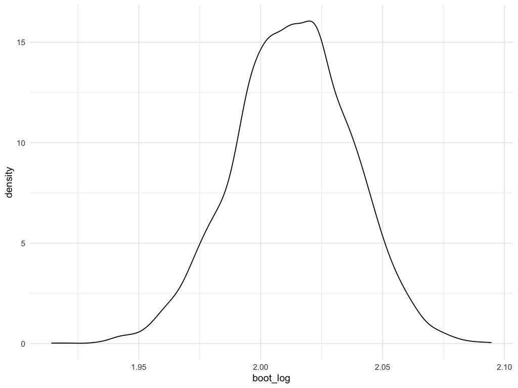

```r
weather_df_bootstrap_2 %>%
  ggplot(aes(x = boot_log)) + geom_density()
```

Determine the 95% CI for r_squared and log(intercept_hat*tmin_hat)

```r
weather_df_bootstrap_2 %>%
  mutate(
    ci_lower_r_squared = quantile(r_squared, 0.025),
    ci_upper_r_squared = quantile(r_squared, 0.975),
    ci_lower_boot_log = quantile(boot_log, 0.025),
    ci_upper_boot_log = quantile(boot_log, 0.975),
  )
```

```
## # A tibble: 5,000 x 9
##    id    r_squared intercept  tmin boot_log ci_lower_r_squa… ci_upper_r_squa…
##    <chr>     <dbl>     <dbl> <dbl>    <dbl>            <dbl>            <dbl>
##  1 0001      0.913      7.16  1.02     1.99            0.894            0.928
##  2 0002      0.919      6.98  1.06     2.00            0.894            0.928
##  3 0003      0.907      7.48  1.03     2.04            0.894            0.928
##  4 0004      0.920      7.19  1.06     2.03            0.894            0.928
##  5 0005      0.914      7.43  1.03     2.04            0.894            0.928
##  6 0006      0.920      6.91  1.05     1.98            0.894            0.928
##  7 0007      0.911      7.48  1.03     2.04            0.894            0.928
##  8 0008      0.916      6.92  1.06     1.99            0.894            0.928
##  9 0009      0.900      7.46  1.04     2.05            0.894            0.928
## 10 0010      0.901      7.75  1.00     2.05            0.894            0.928
## # … with 4,990 more rows, and 2 more variables: ci_lower_boot_log <dbl>,
## #   ci_upper_boot_log <dbl>
```

The 95% CI for R_Squared_hat is 0.8942046 - 0.9278335.

The 95% CI for log(intercept_hat*tmin_hat) is 1.9645455 - 2.0586734.